# Practical Machine Learning Course Project

Maya Gershtenson

2025-12-28

## Overview

The goal of this project is to predict the manner in which participants performed an exercise. This is represented by the **classe** variable. Predictions will be made using data from accelerometers worn on the belt, forearm, arm, and dumbbell of participants. There are five different classe outcome categories.

```r
# Load the training data
train <- read.csv("C:/Users/MGershtenson/Downloads/pml-training.csv")

# Convert classe to factor
train$classe <- as.factor(train$classe)
summary(train$classe)
```

```
##    A    B    C    D    E
## 5580 3797 3422 3216 3607
```

## Data Cleaning and Preparation

The dataset contains 160 variables, so as a first step we need to pare this down. I will  
- remove predictors with near-zero variance. Such variables provide little value in making predictions.  
- remove predictors with high proportions of missing values  
- remove variables that will not be useful for prediction, such as user names and timestamps

```r
# Get indices of variables with near-zero variance
nzv_indices <- nearZeroVar(train)
nzv_indices
```

```
##  [1]   6  12  13  14  15  16  17  20  23  26  51  52  53  54  55  56  57  58  59
## [20]  69  70  71  72  73  74  75  78  79  81  82  87  88  89  90  91  92  95  98
## [39] 101 125 126 127 128 129 130 131 133 134 136 137 139 142 143 144 145 146 147
## [58] 148 149 150
```

```r
# Remove the variables with near-zero variance
train_filter <- train[, -nzv_indices]

# Get proportion of missing data for each variable
missing_proportions <- colMeans(is.na(train_filter))
missing_proportions
```

```
##                        X                user_name     raw_timestamp_part_1
##                0.0000000                0.0000000                0.0000000
##     raw_timestamp_part_2           cvtd_timestamp               num_window
##                0.0000000                0.0000000                0.0000000
##                roll_belt               pitch_belt                 yaw_belt
##                0.0000000                0.0000000                0.0000000
##         total_accel_belt            max_roll_belt           max_picth_belt
##                0.0000000                0.9793089                0.9793089
##            min_roll_belt           min_pitch_belt      amplitude_roll_belt
##                0.9793089                0.9793089                0.9793089
##     amplitude_pitch_belt     var_total_accel_belt            avg_roll_belt
##                0.9793089                0.9793089                0.9793089
##         stddev_roll_belt            var_roll_belt           avg_pitch_belt
##                0.9793089                0.9793089                0.9793089
##        stddev_pitch_belt           var_pitch_belt             avg_yaw_belt
##                0.9793089                0.9793089                0.9793089
##          stddev_yaw_belt             var_yaw_belt             gyros_belt_x
##                0.9793089                0.9793089                0.0000000
##             gyros_belt_y             gyros_belt_z             accel_belt_x
##                0.0000000                0.0000000                0.0000000
##             accel_belt_y             accel_belt_z            magnet_belt_x
##                0.0000000                0.0000000                0.0000000
##            magnet_belt_y            magnet_belt_z                 roll_arm
##                0.0000000                0.0000000                0.0000000
##                pitch_arm                  yaw_arm          total_accel_arm
##                0.0000000                0.0000000                0.0000000
##            var_accel_arm              gyros_arm_x              gyros_arm_y
##                0.9793089                0.0000000                0.0000000
##              gyros_arm_z              accel_arm_x              accel_arm_y
##                0.0000000                0.0000000                0.0000000
##              accel_arm_z             magnet_arm_x             magnet_arm_y
##                0.0000000                0.0000000                0.0000000
##             magnet_arm_z            max_picth_arm              max_yaw_arm
##                0.0000000                0.9793089                0.9793089
##              min_yaw_arm        amplitude_yaw_arm            roll_dumbbell
##                0.9793089                0.9793089                0.0000000
##           pitch_dumbbell             yaw_dumbbell        max_roll_dumbbell
##                0.0000000                0.0000000                0.9793089
##       max_picth_dumbbell        min_roll_dumbbell       min_pitch_dumbbell
##                0.9793089                0.9793089                0.9793089
```

[output cut: 13 more lines]

```
##                0.0000000                0.0000000                0.0000000
##        magnet_dumbbell_z             roll_forearm            pitch_forearm
##                0.0000000                0.0000000                0.0000000
##              yaw_forearm        max_picth_forearm        min_pitch_forearm
##                0.0000000                0.9793089                0.9793089
##  amplitude_pitch_forearm      total_accel_forearm        var_accel_forearm
##                0.9793089                0.0000000                0.9793089
##          gyros_forearm_x          gyros_forearm_y          gyros_forearm_z
##                0.0000000                0.0000000                0.0000000
##          accel_forearm_x          accel_forearm_y          accel_forearm_z
##                0.0000000                0.0000000                0.0000000
##         magnet_forearm_x         magnet_forearm_y         magnet_forearm_z
##                0.0000000                0.0000000                0.0000000
##                   classe
##                0.0000000
```

```r
table(missing_proportions)
```

```
## missing_proportions
##                 0 0.979308938946081
##                59                41
```

```r
# Since all variables have either 0 or 98% missing data,
# remove the variables with any missing data
train_filter <- train_filter[, colSums(is.na(train_filter)) == 0]

# Remove variables with 'timestamp' in column name
columns_to_keep <- names(train_filter)[!grepl("timestamp", names(train_filter))]
columns_to_keep
```

```
##  [1] "X"                    "user_name"            "num_window"
##  [4] "roll_belt"            "pitch_belt"           "yaw_belt"
##  [7] "total_accel_belt"     "gyros_belt_x"         "gyros_belt_y"
## [10] "gyros_belt_z"         "accel_belt_x"         "accel_belt_y"
## [13] "accel_belt_z"         "magnet_belt_x"        "magnet_belt_y"
## [16] "magnet_belt_z"        "roll_arm"             "pitch_arm"
## [19] "yaw_arm"              "total_accel_arm"      "gyros_arm_x"
## [22] "gyros_arm_y"          "gyros_arm_z"          "accel_arm_x"
## [25] "accel_arm_y"          "accel_arm_z"          "magnet_arm_x"
## [28] "magnet_arm_y"         "magnet_arm_z"         "roll_dumbbell"
## [31] "pitch_dumbbell"       "yaw_dumbbell"         "total_accel_dumbbell"
## [34] "gyros_dumbbell_x"     "gyros_dumbbell_y"     "gyros_dumbbell_z"
## [37] "accel_dumbbell_x"     "accel_dumbbell_y"     "accel_dumbbell_z"
## [40] "magnet_dumbbell_x"    "magnet_dumbbell_y"    "magnet_dumbbell_z"
## [43] "roll_forearm"         "pitch_forearm"        "yaw_forearm"
## [46] "total_accel_forearm"  "gyros_forearm_x"      "gyros_forearm_y"
## [49] "gyros_forearm_z"      "accel_forearm_x"      "accel_forearm_y"
## [52] "accel_forearm_z"      "magnet_forearm_x"     "magnet_forearm_y"
## [55] "magnet_forearm_z"     "classe"
```

```r
train_filter <- train_filter[, columns_to_keep]

# Remove other unhelpful variables
train_filter <- train_filter[, -c(1, 2, 3)]
```

## Plots

I will plot a few combinations of predictors to get a sense of how the data look and which variables might be important in predicting classe.

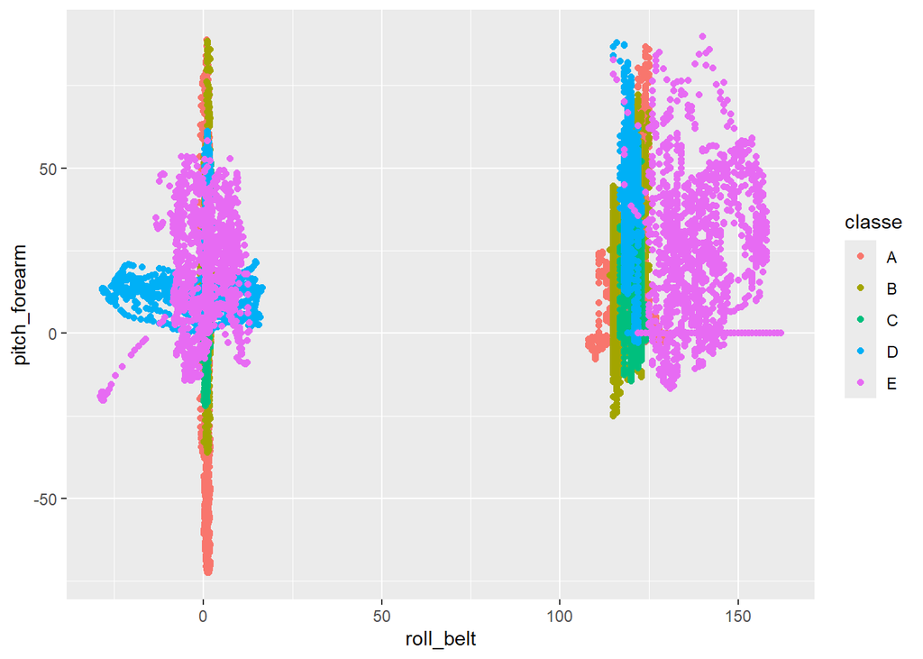

```r
qplot(roll_belt, pitch_forearm, colour=classe, data=train_filter)
```

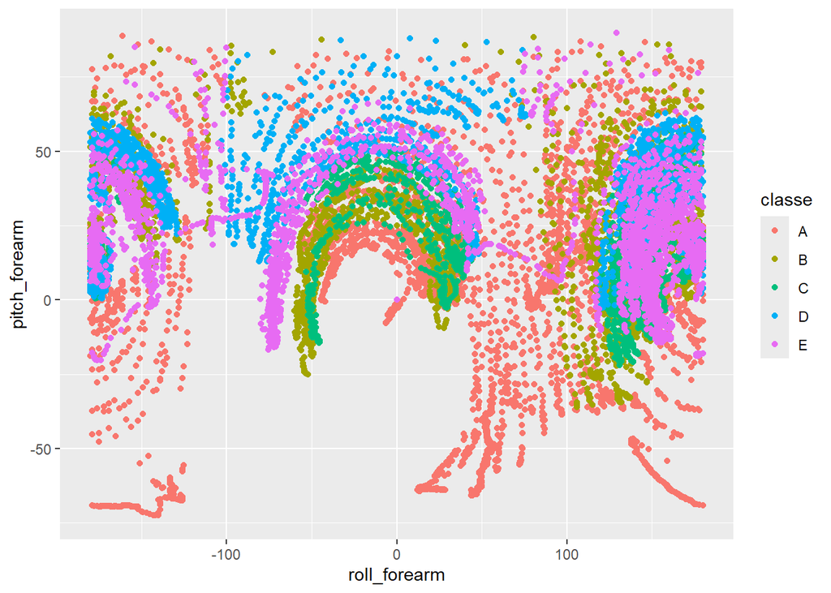

```r
qplot(roll_forearm, pitch_forearm, colour=classe, data=train_filter)
```

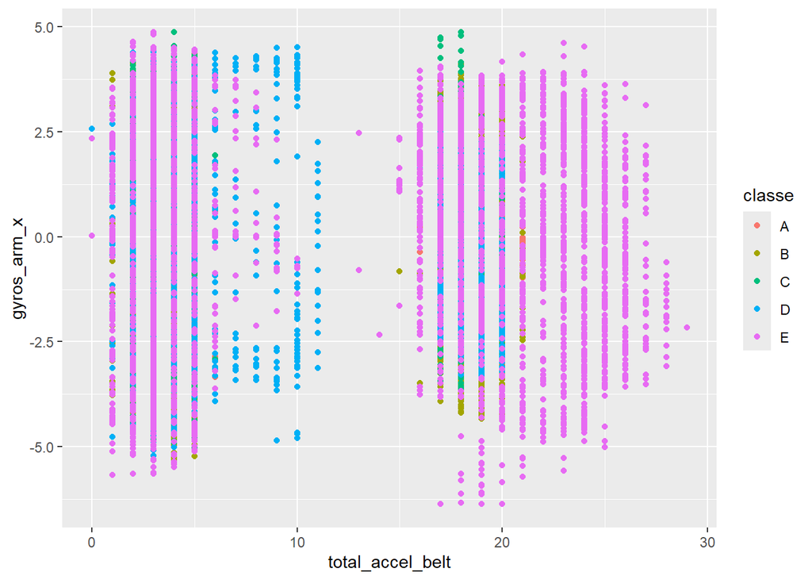

```r
qplot(total_accel_belt, gyros_arm_x, colour=classe, data=train_filter)
```

## Cross-Validation

I will use cross-validation, splitting the training data into 5 folds and training the model on different subsets of the data. This value of k for k-fold cross-validation will strike a balance between the high variance obtained with a larger k and the high bias obtained with a smaller k.

```r
train_control <- trainControl(method="cv", number=5)
```

## Model Training

I chose to use a classification tree because  
- it is highly interpretable  
- it performs well in nonlinear settings

I will use all the variables remaining after the data cleaning steps above to predict classe. These variables are all viable predictors because they do not contain any missing data, and they do not have near-zero variance. I will also include cross-validation, as described above, in training the model.

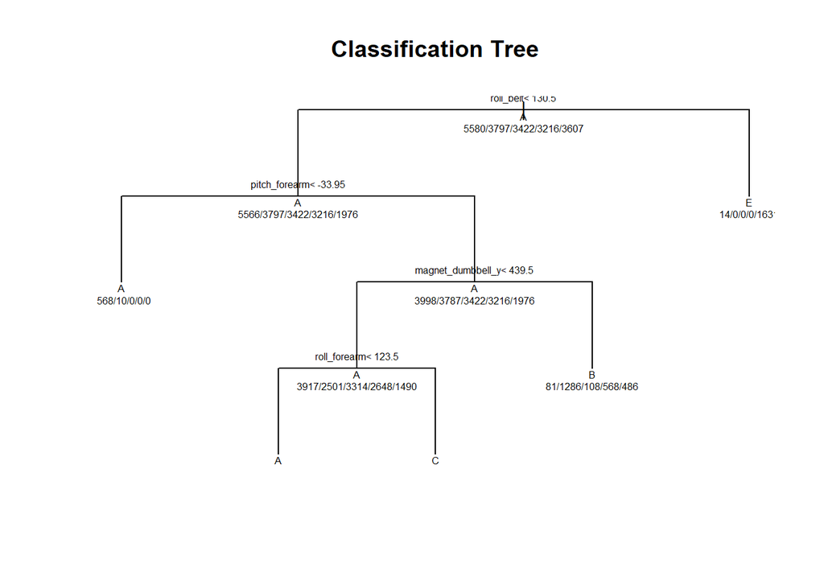

```r
# Fit the classification tree
fit <- train(classe ~ ., method="rpart", data=train_filter, trControl = train_control)

# Plot the classification tree
plot(fit$finalModel, uniform=TRUE, main="Classification Tree")
text(fit$finalModel, use.n=TRUE, all=TRUE, cex=.5)
```

## Expected Out-of-Sample Error

```r
# Get the confusion matrix for the classification tree
confusionMatrix(fit)
```

```
## Cross-Validated (5 fold) Confusion Matrix
##
## (entries are percentual average cell counts across resamples)
##
##           Reference
## Prediction    A    B    C    D    E
##          A 25.8  8.1  8.1  7.3  2.7
##          B  0.5  6.6  0.6  2.9  2.5
##          C  1.8  3.2  8.0  3.9  3.3
##          D  0.3  1.5  0.7  2.2  1.6
##          E  0.1  0.0  0.0  0.0  8.3
##
##  Accuracy (average) : 0.5094
```

## Predict Test Cases

Now I will load the testing dataset and use the classification tree built on the training dataset to predict **classe** in the testing dataset.

```r
# Load the testing data
test <- read.csv("C:/Users/MGershtenson/Downloads/pml-testing.csv")

# Predict new values
predict(fit, newdata=test)
```

```
##  [1] C A C A A C C A A A C C C A C A A A A C
## Levels: A B C D E
```